# Introduction

Published

June 5, 2023

## Introduction

Housekeeping, introductions

## Key Concepts Across Both languages

### Core Libraries

- Spatial data structures across languages and applications is primarily organized through [OSgeo](https://www.osgeo.org) and [OGC](https://www.ogc.org)) *and* a few core libraries underpin spatial libraries in programming languages and in software applications(R, Python, QGIS, ArcPro)!

These libraries include:

- **PROJ** –> Spatial projections, transformations
- **GEOS** –> Geometry operations (measures, relations)
- **GDAL** –> Raster and feature abstraction and processing (read, write)
- **NetCDF** –> Multidimensional (XYZT) data abstraction (read, write)

### Requesting web services (APIs)

More and more data is available as web services, and the data is stored in a remote server in JSON, XML, HTML format which is accessible through API’s.

**JSON** (JavaScript Object Notation) is a lightweight data-interchange format which is easy for machines to generate and parse; easy for humans to write and read.

Sample JSON format : { “data”: “Click Here”, “size”: 36, “style”: “bold”, “name”: “text1”, }

**API** - An Application Programming Interface (API) takes a structured request from an application and returns structured results from the host application. With a **Rest API** you’re getting a representation of the requested data stored in a server. A **Rest API** also is what we call ‘stateless’, which means a server doesn’t store any data between requests from clients.

**Rest APIs** access data through **uniform resource identifiers (URIs)**, which are essentially a string of characters that identify a specific resource. The type of URI used by a **Rest API** is a **uniform resource locator (URL)**.

**HTTP** clients are used for accessing the API. **HyperText Transfer Protocol (HTTP)** enables communication between the client and server using **HTTP** methods. If we want to access or manipulate resources a **Rest API** uses specific request verbs we need to become familiar with:

- GET: used to acquire data from a database
- POST: used to add data to a database
- PUT: update the data in a database
- DELETE: delete data in a database

### Geospatial data representation fundamentals: simple features and geospatial grids

- ***Vector** data are comprised of points, lines, and polygons that represent discrete spatial entities, such as a river, watershed, or stream gauge.
- **Raster** data divides spaces into rectilinear cells (pixels) to represent spatially continuous phenomena, such as elevation or the weather. The cell size (or resolution) defines the fidelity of the data.

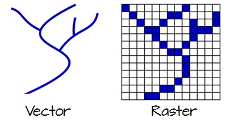

For *Vector* data Simple Features (officially Simple Feature Access) is both an OGC and International Organization for Standardization (ISO) standard that specifies how (mostly) two-dimensional geometries can represent and describe objects in the real world. Simple features includes:

- a class hierarchy
- a set of operations
- binary and text encodings

It describes how such objects can be stored in and retrieved from databases, and which geometrical operations should be defined for them.

It outlines how the spatial elements of POINTS (XY locations with a specific coordinate reference system) extend to LINES, POLYGONS and GEOMETRYCOLLECTION(s).

The “simple” adjective also refers to the fact that the line or polygon geometries are represented by sequences of points connected with straight lines that do not self-intersect.

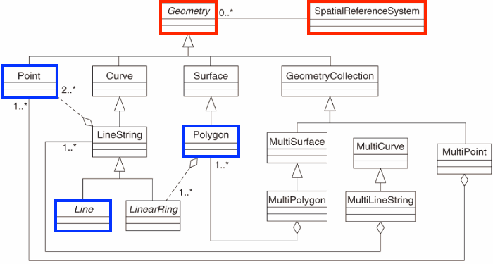

#### Simple and valid geometries and ring direction

This breakdown of simple features follows for the most part [this section in Spatial Data Science](https://r-spatial.org/book/03-Geometries.html) For *linestrings* to be considered *simple* they must not self-intersect:

```r
library(sf)
(ls <- st_linestring(rbind(c(0,0), c(1,1), c(2,2), c(0,2), c(1,1), c(2,0))))
```

```
LINESTRING (0 0, 1 1, 2 2, 0 2, 1 1, 2 0)
```

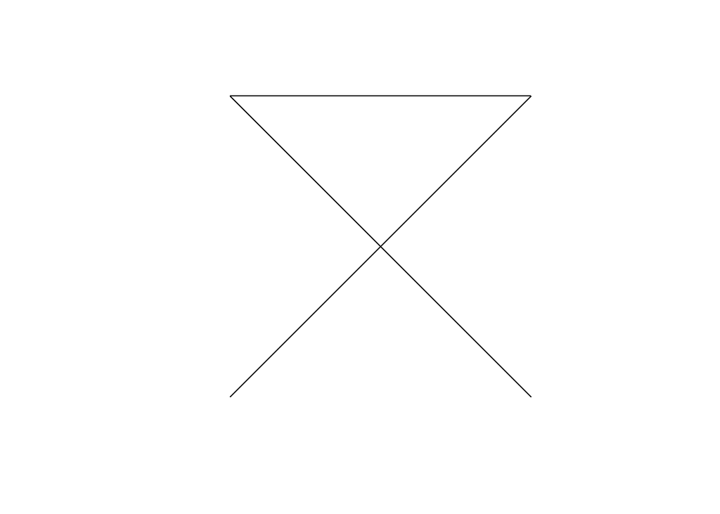

```
is_simple
    FALSE
```

For *polygons* several other conditions have to be met to be *simple*:

- polygon rings are closed (the last point equals the first)
- polygon holes (inner rings) are inside their exterior ring
- polygon inner rings maximally touch the exterior ring in single points, not over a line
- a polygon ring does not repeat its own path
- in a multi-polygon, an external ring maximally touches another exterior ring in single points, not over a line

*z* and *m* coordinates As well as having the necessary X and Y coordinates, single point (vertex) simple features can have:

- a Z coordinate, denoting altitude, and/or
- an M value, denoting some “measure”

**Text and binary encodings** A key part of the standard feature encoding is **text** and **binary** encodings. The well-known text (WKT) encoding we have shown above gives us a human-readable description of the geometry. The well-known binary (WKB) encoding is machine-readable, lossless, and faster to work with than text encoding. WKB is used for all interactions with `GDAL` and `GEOS`.

**Operations on geometries** We can break down operations on geometries for *vector* features in the following way:

- **predicates**: a logical asserting a certain property is `TRUE`
- **measures**: a quantity (a numeric value, possibly with measurement unit)
- **transformations**: newly generated geometries

We can look at these operations by **what** they operate on, whether the are single geometries, pairs, or sets of geometries:

- **unary** when it’s a single geometry
- **binary** when it’s pairs of geometries
- **n-ary** when it’s sets of geometries

**Unary** predicates work to describe a property of a geometry.

A list of unary predicates:

| predicate | meaning |
| --- | --- |
| `is` | Tests if geometry belongs to a particular class |
| `is_simple` | Tests whether geometry is simple |
| `is_valid` | Test whether geometry is valid |
| `is_empty` | Tests if geometry is empty |

A list of binary predicates is:

| predicate | meaning | inverse of |
| --- | --- | --- |
| `contains` | None of the points of A are outside B | `within` |
| `contains_properly` | A contains B and B has no points in common with the boundary of A |  |
| `covers` | No points of B lie in the exterior of A | `covered_by` |
| `covered_by` | Inverse of `covers` |  |
| `crosses` | A and B have some but not all interior points in common |  |
| `disjoint` | A and B have no points in common | `intersects` |
| `equals` | A and B are topologically equal: node order or number of nodes may differ; identical to A contains B and A within B |  |
| `equals_exact` | A and B are geometrically equal, and have identical node order |  |
| `intersects` | A and B are not disjoint | `disjoint` |
| `is_within_distance` | A is closer to B than a given distance |  |
| `within` | None of the points of B are outside A | `contains` |
| `touches` | A and B have at least one boundary point in common, but no interior points |  |
| `overlaps` | A and B have some points in common; the dimension of these is identical to that of A and B |  |
| `relate` | Given a mask pattern, return whether A and B adhere to this pattern |  |

See the [Geometries chapter of Spatial Data Science](https://r-spatial.org/book/03-Geometries.html) for a full treatment that also covers **unary and binary measures* as well as *unary, binary and n-ary transformers*

#### Raster data model

You can read the [GDAL raster data model](https://gdal.org/user/raster_data_model.html) and [OpenGIS Grid Coverages specification](https://docs.geotools.org/stable/javadocs/org/opengis/coverage/grid/package-summary.html) but with a raster data model (a cell-based tesselation) you can read / write and operate on raster data in numerous formats using **gdal**:

|  | name | type | can | vsi | long.name |
| --- | --- | --- | --- | --- | --- |
| 1 | AAIGrid | raster | read/write | True | Arc/Info ASCII Grid |
| 2 | ACE2 | raster | read | True | ACE2 |
| 3 | ADRG | raster | read/write | True | ARC Digitized Raster Graphics |
| 4 | AIG | raster | read | True | Arc/Info Binary Grid |
| 5 | AirSAR | raster | read | True | AirSAR Polarimetric Image |
| 6 | ARG | raster | read/write | True | Azavea Raster Grid format |
| 7 | BAG | raster | read/write | True | Bathymetry Attributed Grid |
| 8 | BIGGIF | raster | read | True | Graphics Interchange Format (.gif) |
| 9 | BLX | raster | read/write | True | Magellan topo (.blx) |
| 10 | BMP | raster | read/write | True | MS Windows Device Independent Bitmap |

[output cut: 193 more lines]

### Drainage basins and catchments - mainstems and flowpaths

When writing software for hydrologic data, concrete conceptual and logical definitions for the spatial features our software works with are critical to enabling interoperability. Along these lines, some key definitions to consider:

- **Catchment**: A physiographic unit with zero or one inlets and one outlet. A catchment is represented by one or more partial realizations; flowpath, divide, and networks of flowpaths and divides.
- **Nexus**: Conceptual outlet for water contained by a catchment. The hydro nexus concept represents the place where a catchment interacts with another catchment.
- **Flowpath**: A flowpath is a linear geometry that represents the connection between a catchment’s inlet and its outlet. All flowpaths have a local drainage area and may be aggregates of flowlines.
- **Flowline**: A flowline is a linear geometry that represents a segment of a flowing body of water. Some flowlines have no local drainage area and are never aggregate features.
- **Drainage Basin**: A catchment with zero inlets and one (internal or external) outlet.
- **Mainstem**: The flowpath of a drainage basin.

In the following, we create a representation of catchment divides and flowpaths with the hydrologic locations that represent their nexuses.

**Note:** both the divide and flowpath are said to be realizations of the overall catchment that they represent. In other words, the divide and flowpath are both part of the representation of a catchment.

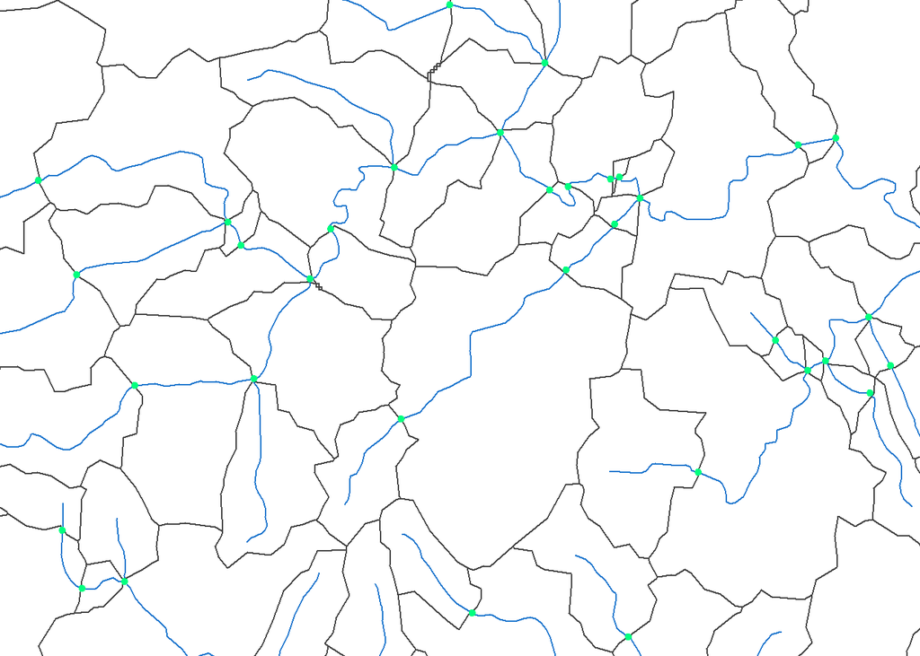

```r
source(system.file("extdata/new_hope_data.R", package = "nhdplusTools"))

catchment <- sf::st_geometry(new_hope_catchment)
flowpath <- sf::st_geometry(dplyr::filter(new_hope_flowline, COMID %in% new_hope_catchment$FEATUREID))
nexus <- sf::st_geometry(nhdplusTools::get_node(flowpath, "end"))


plot_window <- sf::st_as_sfc(sf::st_bbox(dplyr::filter(new_hope_catchment, FEATUREID %in% c(8891178, 8895564))))

par(mar = c(0,0,0,0))
plot(plot_window, col = NA, border = NA)
plot(catchment, col = NA, border = "grey25", add = TRUE)
plot(flowpath, col = "dodgerblue3", add = TRUE)
plot(nexus, col = "springgreen", add = TRUE, pch = 20)
```

In this example, we create a drainage basin boundary (divide), mainstem flowpath of the drainage basin, and the flowlines that make up the hydrographic network of the drainage basin.

**Fun Fact:** the word “watershed” has come to refer to the land encompassed by a drainage divide but this usage is not correct. A watershed is “a dividing ridge between drainage areas” which is in line with the non hydrologic use of the word: a crucial dividing point, line, or factor.

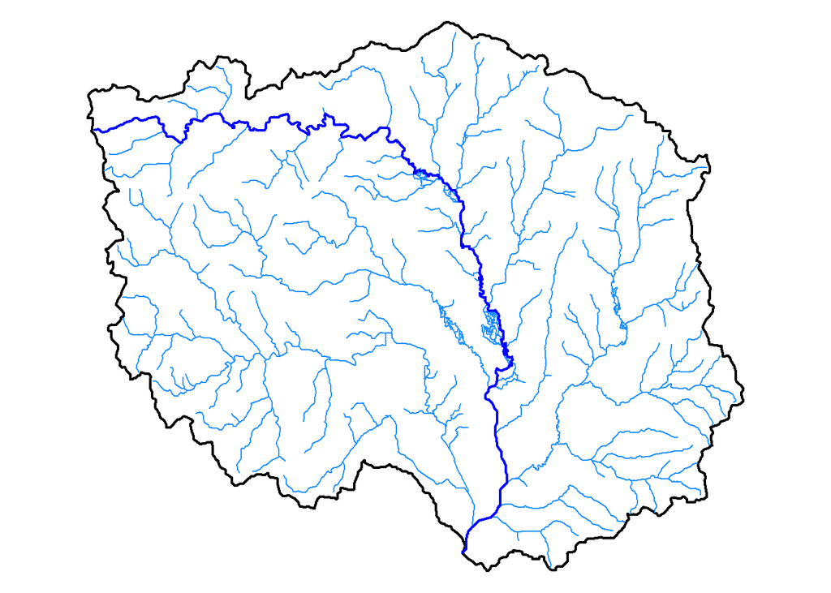

```r
basin <- sf::st_geometry(sf::st_union(new_hope_catchment, by_feature = FALSE))
flowline <- sf::st_geometry(new_hope_flowline)
mainstem <- sf::st_geometry(new_hope_flowline[new_hope_flowline$LevelPathI == min(new_hope_flowline$LevelPathI),])

par(mar = c(0,0,0,0))
plot(basin, lwd = 2)
plot(flowline, col = "dodgerblue", add = TRUE)
plot(mainstem, col = "blue", lwd = 2, add = TRUE)
```

## Demonstration of Key Concepts in Each Language

- drainage basins and catchments - mainstems and flowpaths
- geospatial data representation fundamentals, simple features and geospatial grids

### Examples in R

#### sf: simple features

In R, the [`sf` package](https://cran.r-project.org/web/packages/sf/index.html) provides “*support for simple features, a standardized way to encode spatial vector data…. [and] Binds to ‘GDAL’ for reading and writing data, to ‘GEOS’ for geometrical operations, and to ‘PROJ’ for projection conversions and datum transformations.*”

When using R, you’ are’re using an interface to the core community standards, software, and practices (this isn’t exclusive to R). TO highlight this we can install (do this once) and attach `sf` to view the external dependencies versions of the libraries linked to `sf`.

```r
# install.packages("sf")
library(sf)

sf_extSoftVersion()
```

```
          GEOS           GDAL         proj.4 GDAL_with_GEOS     USE_PROJ_H
      "3.11.1"        "3.6.2"        "9.1.1"         "true"         "true"
          PROJ
       "9.1.1"
```

In the `sf` implementation in the R ecosystem stores simple feature geometries (sfg) as part of a larger data.frame using a simple feature geometry list-column (sfg). The collection of attribute and spatial information define a simple feature that can be operated on in both table (SQL) and spatial (GEOS, etc) contexts. Not only does this allow us to make the most use of the growing spatial community but *also* of the growing data science community (see `ggplot`, `dplyr`, `data.table`, `dbplyr`, `arrow`, etc.)

We can break this down following examples presented in the recently published [Spatial Data Science](https://r-spatial.org/book/03-Geometries.html) by Edzar Pebesma and Rober Bivand. The most common simple feature geometries used to represent a *single* feature are:

| type | description |
| --- | --- |
| `POINT` | single point geometry |
| `MULTIPOINT` | set of points |
| `LINESTRING` | single linestring (two or more points connected by straight lines) |
| `MULTILINESTRING` | set of linestrings |
| `POLYGON` | exterior ring with zero or more inner rings, denoting holes |
| `MULTIPOLYGON` | set of polygons |
| `GEOMETRYCOLLECTION` | set of the geometries above |

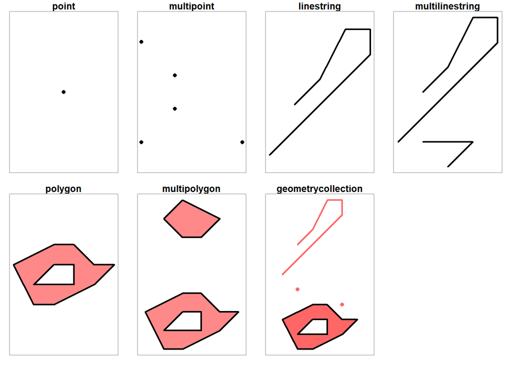

```r
library(sf) |> suppressPackageStartupMessages()
par(mfrow = c(2,4))
par(mar = c(1,1,1.2,1))

# 1
p <- st_point(0:1)
plot(p, pch = 16)
title("point")
box(col = 'grey')

# 2
mp <- st_multipoint(rbind(c(1,1), c(2, 2), c(4, 1), c(2, 3), c(1,4)))
plot(mp, pch = 16)
title("multipoint")
box(col = 'grey')

# 3
ls <- st_linestring(rbind(c(1,1), c(5,5), c(5, 6), c(4, 6), c(3, 4), c(2, 3)))
plot(ls, lwd = 2)
title("linestring")
box(col = 'grey')

# 4
mls <- st_multilinestring(list(
  rbind(c(1,1), c(5,5), c(5, 6), c(4, 6), c(3, 4), c(2, 3)),
  rbind(c(3,0), c(4,1), c(2,1))))
plot(mls, lwd = 2)
title("multilinestring")
box(col = 'grey')

# 5 polygon
po <- st_polygon(list(rbind(c(2,1), c(3,1), c(5,2), c(6,3), c(5,3), c(4,4), c(3,4), c(1,3), c(2,1)),
    rbind(c(2,2), c(3,3), c(4,3), c(4,2), c(2,2))))
plot(po, border = 'black', col = '#ff8888', lwd = 2)
title("polygon")
box(col = 'grey')

# 6 multipolygon
mpo <- st_multipolygon(list(
    list(rbind(c(2,1), c(3,1), c(5,2), c(6,3), c(5,3), c(4,4), c(3,4), c(1,3), c(2,1)),
        rbind(c(2,2), c(3,3), c(4,3), c(4,2), c(2,2))),
    list(rbind(c(3,7), c(4,7), c(5,8), c(3,9), c(2,8), c(3,7)))))
plot(mpo, border = 'black', col = '#ff8888', lwd = 2)
title("multipolygon")
box(col = 'grey')

# 7 geometrycollection
gc <- st_geometrycollection(list(po, ls + c(0,5), st_point(c(2,5)), st_point(c(5,4))))
plot(gc, border = 'black', col = '#ff6666', pch = 16, lwd = 2)
title("geometrycollection")
box(col = 'grey')
```

```r
p
```

```
POINT (0 1)
```

```r
mp
```

```
MULTIPOINT ((1 1), (2 2), (4 1), (2 3), (1 4))
```

```r
ls
```

```
LINESTRING (1 1, 5 5, 5 6, 4 6, 3 4, 2 3)
```

```r
mls
```

```
MULTILINESTRING ((1 1, 5 5, 5 6, 4 6, 3 4, 2 3), (3 0, 4 1, 2 1))
```

```r
po
```

```
POLYGON ((2 1, 3 1, 5 2, 6 3, 5 3, 4 4, 3 4, 1 3, 2 1), (2 2, 3 3, 4 3, 4 2, 2 2))
```

```r
mpo
```

```
MULTIPOLYGON (((2 1, 3 1, 5 2, 6 3, 5 3, 4 4, 3 4, 1 3, 2 1), (2 2, 3 3, 4 3, 4 2, 2 2)), ((3 7, 4 7, 5 8, 3 9, 2 8, 3 7)))
```

```r
gc
```

```
GEOMETRYCOLLECTION (POLYGON ((2 1, 3 1, 5 2, 6 3, 5 3, 4 4, 3 4, 1 3, 2 1), (2 2, 3 3, 4 3, 4 2, 2 2)), LINESTRING (1 6, 5 10, 5 11, 4 11, 3 9, 2 8), POINT (2 5), POINT (5 4))
```

This extends the idea of [“tidy” data](https://cran.r-project.org/web/packages/tidyr/vignettes/tidy-data.html) in that each row represents one observation, which has one geometric representation of the real world feature it describes.

An example of basic use:

```r
# Define file path
filename <- system.file("shape/nc.shp", package="sf")

# read in file
(nc <- read_sf(filename))
```

```
Simple feature collection with 100 features and 14 fields
Geometry type: MULTIPOLYGON
Dimension:     XY
Bounding box:  xmin: -84.32385 ymin: 33.88199 xmax: -75.45698 ymax: 36.58965
Geodetic CRS:  NAD27
# A tibble: 100 × 15
    AREA PERIMETER CNTY_ CNTY_ID NAME  FIPS  FIPSNO CRESS_ID BIR74 SID74 NWBIR74
   <dbl>     <dbl> <dbl>   <dbl> <chr> <chr>  <dbl>    <int> <dbl> <dbl>   <dbl>
 1 0.114      1.44  1825    1825 Ashe  37009  37009        5  1091     1      10
 2 0.061      1.23  1827    1827 Alle… 37005  37005        3   487     0      10
 3 0.143      1.63  1828    1828 Surry 37171  37171       86  3188     5     208
 4 0.07       2.97  1831    1831 Curr… 37053  37053       27   508     1     123
 5 0.153      2.21  1832    1832 Nort… 37131  37131       66  1421     9    1066
 6 0.097      1.67  1833    1833 Hert… 37091  37091       46  1452     7     954
 7 0.062      1.55  1834    1834 Camd… 37029  37029       15   286     0     115
 8 0.091      1.28  1835    1835 Gates 37073  37073       37   420     0     254
 9 0.118      1.42  1836    1836 Warr… 37185  37185       93   968     4     748
10 0.124      1.43  1837    1837 Stok… 37169  37169       85  1612     1     160
# ℹ 90 more rows
# ℹ 4 more variables: BIR79 <dbl>, SID79 <dbl>, NWBIR79 <dbl>,
#   geometry <MULTIPOLYGON [°]>
```

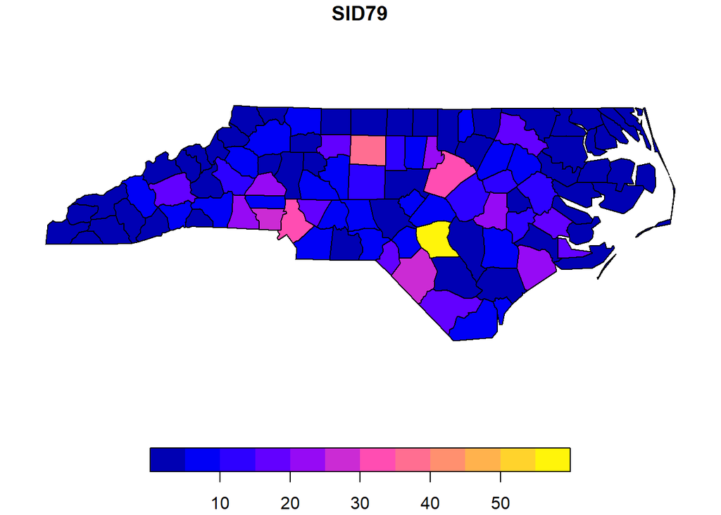

```r
# Map
plot(nc['SID79'])
```

```r
# Spatial measures!
head(st_area(nc))
```

```
Units: [m^2]
[1] 1137107793  610916077 1423145355  694378925 1520366979  967504822
```

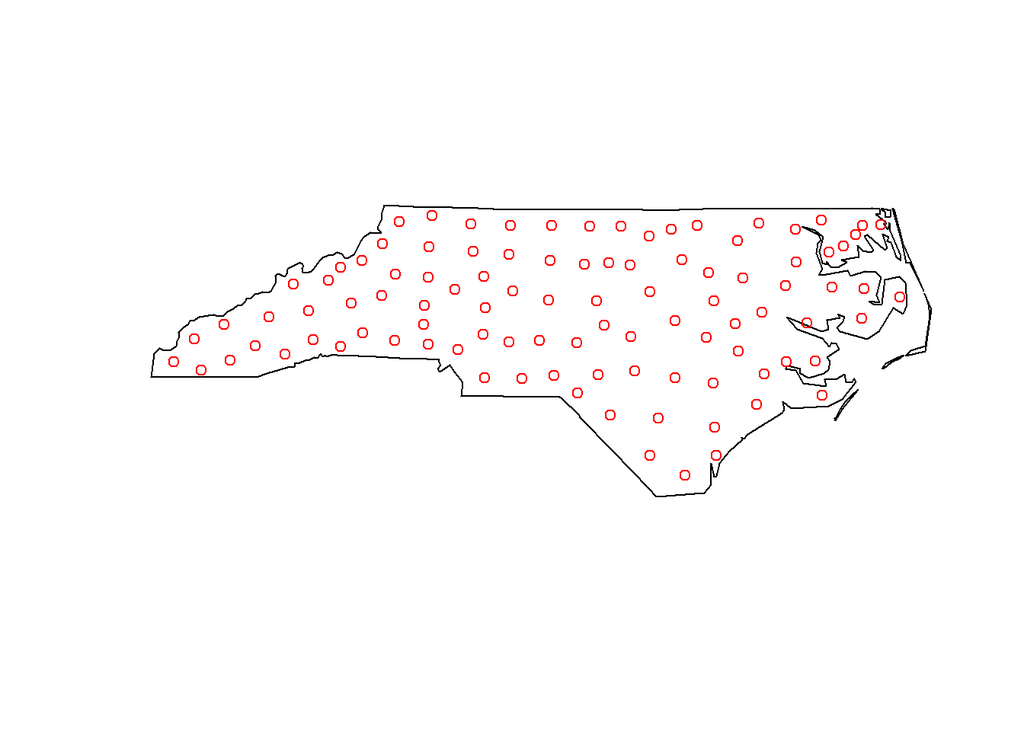

```r
# Spatial operations!
{
  st_union(nc) |> plot()

  st_centroid(nc)$geometry |> plot(col = "red", add = TRUE)
}
```

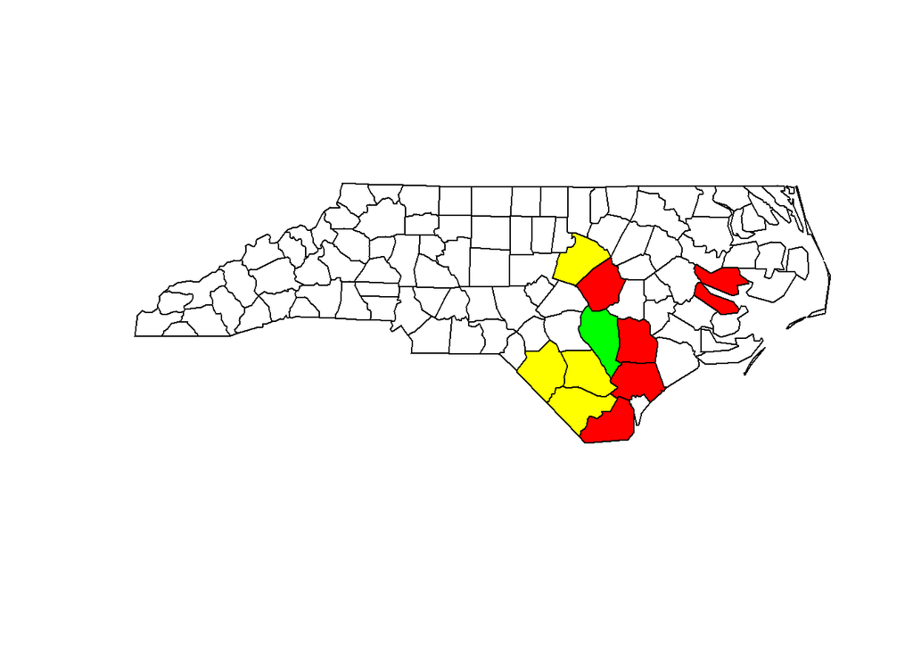

```r
# data science operations
library(dplyr)
{
 plot(nc$geometry)
 plot(slice_max(nc, AREA, n = 10)$geometry,
      col = "red", add = TRUE)
 plot(slice_max(nc, AREA, n =5)$geometry,
      col = "yellow", add = TRUE)
 plot(slice_max(nc, AREA, n = 1)$geometry,
      col = "green", add = TRUE)
}
```

#### Measure (GEOS Measures)

Measures are the questions we ask about the dimension of a geometry, once a coordinate reference system has been established and we can compute: - How long is a line or polygon perimeter? (unit) - What is the area of a polygon? *(unit^2) - How far are two objects from one another? (unit)

- *Measures* come from the GEOS library
- *Measures* are calculated in the **units** of the projection

We’ll demonstrate with a toy dataset of USGS gages in a data package from a previous workshop:

```r
# remotes::install_github("mhweber/awra2020spatial")
gages <- read.csv(system.file("extdata", "Gages_flowdata.csv", package = "awra2020spatial")) |>
  dplyr::select(SOURCE_FEA, STATE, LAT_SITE, LON_SITE)
```

```
Rows: 2,771
Columns: 4
$ SOURCE_FEA <int> 14361500, 14344500, 10378500, 14341500, 14343000, 13092500,…
$ STATE      <chr> "OR", "OR", "OR", "OR", "OR", "ID", "OR", "OR", "OR", "OR",…
$ LAT_SITE   <dbl> 42.43040, 42.42763, 42.42488, 42.40819, 42.40263, 42.39648,…
$ LON_SITE   <dbl> -123.3178, -122.6011, -119.9233, -122.6011, -122.5373, -114…
```

Using `st_as_sf` in `sf` we can easily make a data frame with coordinates into a simple features data frame

```r
gages <- gages |>
  sf::st_as_sf(coords = c("LON_SITE", "LAT_SITE"), crs = 4269)
```

```
Rows: 2,771
Columns: 3
$ SOURCE_FEA <int> 14361500, 14344500, 10378500, 14341500, 14343000, 13092500,…
$ STATE      <chr> "OR", "OR", "OR", "OR", "OR", "ID", "OR", "OR", "OR", "OR",…
$ geometry   <POINT [°]> POINT (-123.3178 42.4304), POINT (-122.6011 42.42763)…
```

What is the distance from the first stream gage to the second stream gage?

```r
sf::st_distance(gages[1,], gages[2,])
```

```
Units: [m]
         [,1]
[1,] 58822.95
```

We can generate toy area by buffering a point (to make a polygon) and find area and perimeter. We need to project into a planar CRS to get perimeter so we will project to an Albers projection using an `epsg` code:

```r
poly <- sf::st_buffer(gages[1,],200)
sf::st_area(poly)
```

```
127234.3 [m^2]
```

```r
poly <- sf::st_transform(poly, 5070)
lwgeom::st_perimeter(poly)
```

```
1713.517 [m]
```

#### terra and stars

For accessing raster data - first look at terra:

```r
# install.packages(terra)
library(terra)

gdal()
```

```
[1] "3.6.2"
```

```r
DT::datatable(gdal(drivers = TRUE))
```

|  | name | type | can | vsi | long.name |
| --- | --- | --- | --- | --- | --- |
| 1 | AAIGrid | raster | read/write | True | Arc/Info ASCII Grid |
| 2 | ACE2 | raster | read | True | ACE2 |
| 3 | ADRG | raster | read/write | True | ARC Digitized Raster Graphics |
| 4 | AIG | raster | read | True | Arc/Info Binary Grid |
| 5 | AirSAR | raster | read | True | AirSAR Polarimetric Image |
| 6 | ARG | raster | read/write | True | Azavea Raster Grid format |
| 7 | BAG | raster | read/write | True | Bathymetry Attributed Grid |
| 8 | BIGGIF | raster | read | True | Graphics Interchange Format (.gif) |
| 9 | BLX | raster | read/write | True | Magellan topo (.blx) |
| 10 | BMP | raster | read/write | True | MS Windows Device Independent Bitmap |

[output cut: 193 more lines]

We can get raster data the [National Map family of APIs](https://apps.nationalmap.gov/services/) and in particular 3DEP Elevation data and work with it using `terra` or `stars`. We’ll use Mike Johnson’s `AOI` package to get a county polygon to use as a template to pass to `terrainr` for our area of interest

```r
library(terrainr)
# remotes::install_github("mikejohnson51/AOI")
library(AOI)
library(mapview)
mapviewOptions(fgb=FALSE)

AOI::aoi_get(list("Corvallis, OR", 10, 10)) |> mapview()
```

[interactive chart not shown]

```r
# aoi <- AOI::aoi_get(state = "OR", county = "Benton")
aoi <- aoi_get(list("Corvallis, OR", 10, 10))
output_tiles <- get_tiles(aoi,
                          services = c("elevation", "ortho"),
                          resolution = 30 # pixel side length in meters
                          )
```

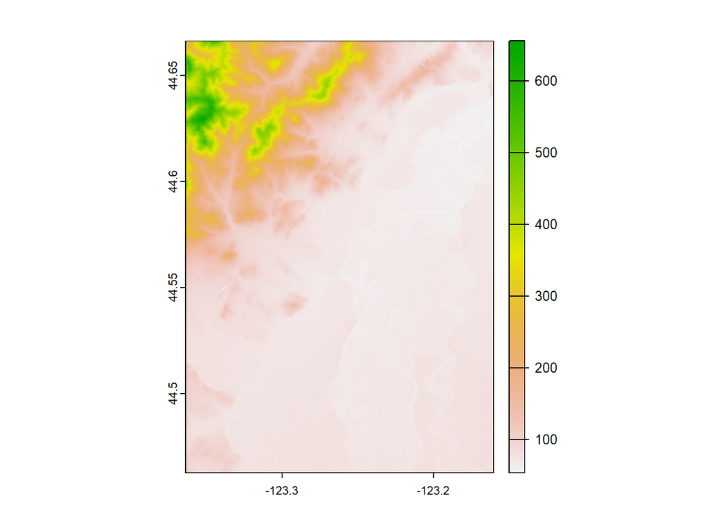

```r
terra::plot(terra::rast(output_tiles[["elevation"]][[1]]))
```

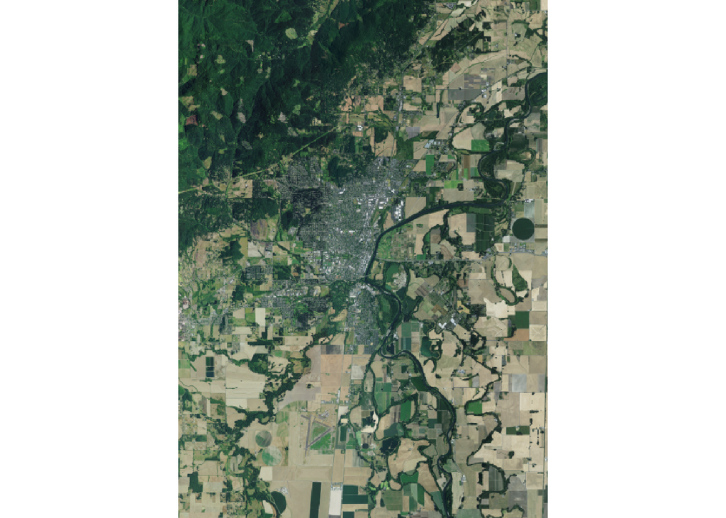

```r
terra::plotRGB(terra::rast(output_tiles[["ortho"]][[1]]),scale = 1)
```

#### httr and jsonlite

In R, httr and jsonlite packages are used to consume the API’s that provide data in json format.

**httr** httr provides us with an HTTP client to access the API with GET/POST methods, passing query parameters, and verifying the response with regard to the data format.

**jsonlite** This R package is used to convert the received json format to readable R object or data frame. `jsonlite` can also be used to convert R objects or a data frame to a json format data type.

Along with these two packages, `rlist` in R can be used to perform additional manipulation on the received json response. `list.stack` and `list.select` are two important methods exposed by `rlist` that can be used to get parsed json data into a `tibble`.

To learn about these (and other) packages, type `?httr`, `?jsonlite` and `?rlist` in the console of Rstudio to view the documentation.

Here we see an example using a JSON API from the world bank that uses a GET request below - we can see a couple ways of passing request parameters - first we’ll embed the query directly in the URL for the request itself:

```r
library(httr)
library(jsonlite)
library(dplyr)
library(data.table)

jsonResponse <- httr::GET("http://api.worldbank.org/country?per_page=10&region=OED&lendingtype=LNX&format=json")
```

We can also generate the query by passing it in a separate list we create and adding as a query parameter in the GET request

```r
query<-list(per_page="10",region="OED",lendingtype="LNX",format="json")
jsonResponse <- httr::GET("http://api.worldbank.org/country",query=query)
```

The `jsonlite` package can be used to parse our response which we indicated above to return as json. Why does the attempt below return an error?

```r
df <- jsonlite::fromJSON(jsonResponse)
```

HINT: what type of object is `jsonResponse` above?

```r
typeof(jsonResponse)
```

```
[1] "list"
```

We can also get information about the response using `httr`:

```r
http_type(jsonResponse)
```

```
[1] "application/json"
```

We have a list - let’s take a look to figure out to pull out what we want into a data frame:

```r
names(jsonResponse)
```

```
 [1] "url"         "status_code" "headers"     "all_headers" "cookies"
 [6] "content"     "date"        "times"       "request"     "handle"
```

It seems like `content` is what we want, how do we pull out?

```r
df <- jsonlite::fromJSON(jsonResponse$content)
```

Still doesn’t work - we need to do some further parsing of this response using `content` in `httr` which we can then pass to `jsonlite` and the `fromJSON` function to get data into a data frame

```r
jsonResponseParsed <- httr::content(jsonResponse, as="parsed")
is.list(jsonResponseParsed)
```

```
[1] TRUE
```

```r
names(jsonResponseParsed[[1]])
```

```
[1] "page"     "pages"    "per_page" "total"
```

```r
names(jsonResponseParsed[[2]])
```

```r
#Hmmm
is.list(jsonResponseParsed[[2]][[1]])
```

```
[1] TRUE
```

```r
names(jsonResponseParsed[[2]][[1]])
```

```
 [1] "id"          "iso2Code"    "name"        "region"      "adminregion"
 [6] "incomeLevel" "lendingType" "capitalCity" "longitude"   "latitude"
```

```r
# now we're getting somewhere...
names(jsonResponseParsed[[2]][[2]])
```

```
 [1] "id"          "iso2Code"    "name"        "region"      "adminregion"
 [6] "incomeLevel" "lendingType" "capitalCity" "longitude"   "latitude"
```

We convert the parsed json response list to data table using `lapply` and `rbindlist`:

```r
df <- lapply(jsonResponseParsed[[2]],as.data.table)
typeof(df) # still a list - one more step
```

```
[1] "list"
```

```r
dt <- rbindlist(df, fill = TRUE)
```

Some APIs like GitHub are easier to pull directly into a dataframe using `fromJSON`

```r
myGitHubRepos <- fromJSON("https://api.github.com/users/mhweber/repos")

# It returns 79 variables about my repos - we can use select to just get the ones we want to see
myGitHubRepos <- myGitHubRepos |>
  dplyr::select(name, stargazers_count, watchers_count, language, has_issues, forks_count)
head(myGitHubRepos)
```

```
                 name stargazers_count watchers_count         language
1 AccumulationScripts                0              0           Python
2          ArrayTools                0              0           Python
3     awra2020spatial                3              3                R
4 AWRA2022GeoWorkshop                6              6 Jupyter Notebook
5 AWRA_2020_R_Spatial                4              4             HTML
6 AWRA_GIS_R_Workshop                2              2       JavaScript
  has_issues forks_count
1       TRUE           0
2      FALSE           0
3       TRUE           0
4       TRUE           5
5       TRUE           2
6       TRUE           3
```

### Examples in Python (will be in a separate notebook in binder)

## Use Cases

### Hydro Addressing

Finding where along a river system some spatial data lies is a key use case for many modeling and analysis tasks. A full discussion is available in the [`nhdplusTools` indexing and referencing vignette.](https://doi-usgs.github.io/nhdplusTools/articles/indexing.html)

We need two inputs. Lines to index to and points that we want addresses for. With these inputs, [`nhdplusTools`](https://doi-usgs.github.io/nhdplusTools/reference/index.html#indexing-and-network-navigation) (and soon [`hydroloom`](https://doi-usgs.github.io/hydroloom/reference/index.html#indexing-and-linear-referencing)) supports generation of hydro addresses with `get_flowline_index()`.

The example below is as simple as possible. `get_flowline_index()` has a number of other capabilities, such as increased address precision and the ability to return multiple nearby addresses, that can be found in the function documentation.

```r
source(system.file("extdata/new_hope_data.R", package = "nhdplusTools"))

fline <- sf::st_transform(sf::st_cast(new_hope_flowline, "LINESTRING"), 4326)

point <- sf::st_sfc(sf::st_point(c(-78.97, 35.916)),
                    crs = 4326)

(address <- nhdplusTools::get_flowline_index(fline, point))
```

```
  id   COMID      REACHCODE REACH_meas       offset
1  1 8894158 03030002000064    58.0596 0.0002283261
```

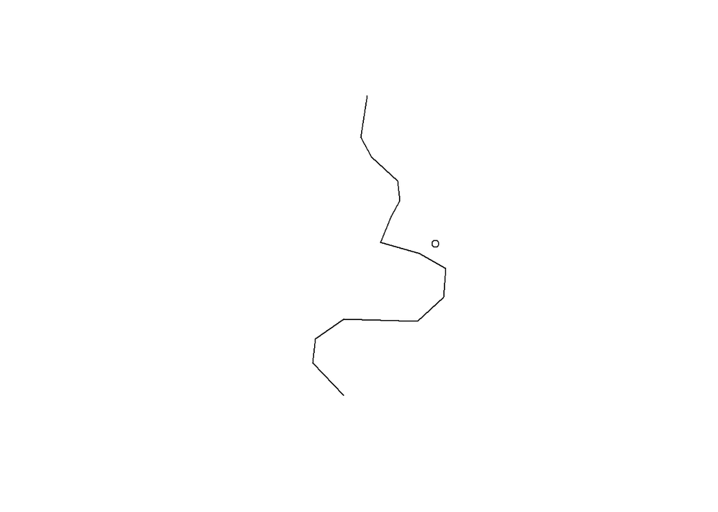

```
integer(0)
```

```r
plot(sf::st_geometry(fline[fline$COMID %in% address$COMID,]))+
  plot(point, add = TRUE)
```

A natural next step once we’ve found a hydro address is to search upstream or downstream from the location we found. [`nhdplusTools`](https://doi-usgs.github.io/nhdplusTools/reference/index.html#network-navigation) and soon [`hydroloom`](https://doi-usgs.github.io/hydroloom/reference/index.html#network-navigation-and-accumulation) offer a few upstream / downstream search functions. Here we’ll show a couple from `nhdplusTools`.

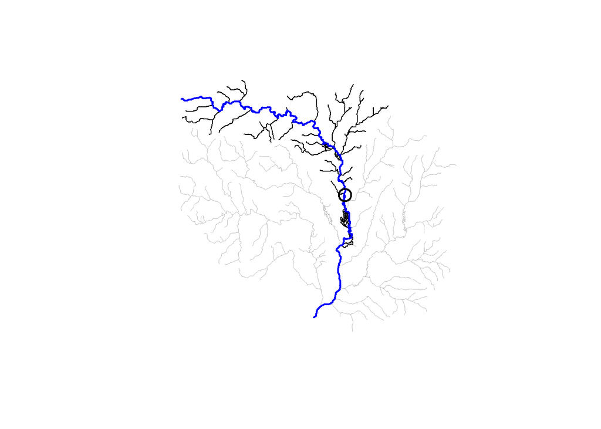

```r
up <- nhdplusTools::get_UT(fline, address$COMID)
um <- nhdplusTools::get_UM(fline, address$COMID)
dn <- nhdplusTools::get_DD(fline, address$COMID)
dm <- nhdplusTools::get_DM(fline, address$COMID)

plot(sf::st_geometry(fline), col = "grey", lwd = 0.5)
plot(sf::st_geometry(fline[fline$COMID %in% c(up, dn),]),
     add = TRUE)
plot(sf::st_geometry(fline[fline$COMID %in% c(um, dm),]),
     col = "blue", lwd = 2, add = TRUE)
plot(point, cex = 2, lwd = 2, add = TRUE)
```

The ability to navigate up or down a mainstem rather than all connected tributaries and diversions, requires some attributes that identify primary up and downstream paths. Without those paths, navigation is still possible but the “main” path navigation method is not. Below, a new function available in `hydroloom`, `navigate_network_dfs()` is shown.

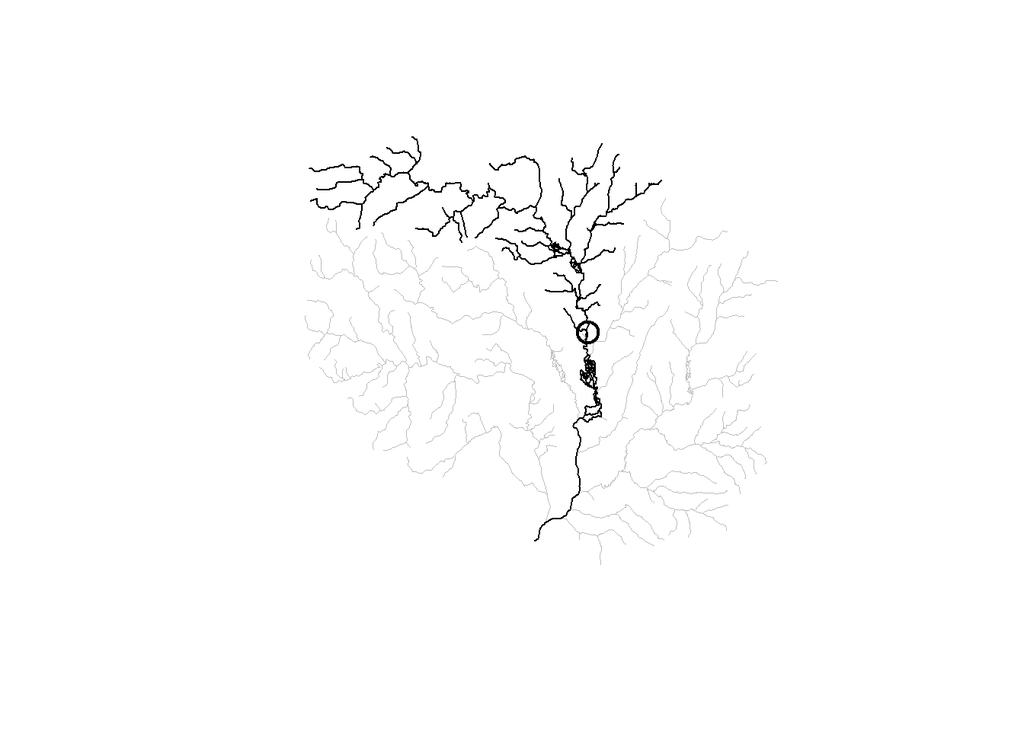

```r
# remotes::install_github("DOI-USGS/nhdplusTools@2cb81da")
#| warning: false
net <- hydroloom::add_toids(sf::st_drop_geometry(fline),
                            return_dendritic = FALSE)

up <- hydroloom::navigate_network_dfs(net, address$COMID, direction = "up")
dn <- hydroloom::navigate_network_dfs(net, address$COMID, direction = "dn")

plot(sf::st_geometry(fline), col = "grey", lwd = 0.5)
plot(sf::st_geometry(fline[fline$COMID %in% c(unlist(up), unlist(dn)),]),
     add = TRUE)
plot(point, cex = 2, lwd = 2, add = TRUE)
```

### Catchment Characteristics and Accumulation

[`nhdplusTools`](https://doi-usgs.github.io/nhdplusTools) (only in the latest `hydroloom` branch) and [`StreamCatTools`](https://usepa.github.io/StreamCatTools) can be used to retrieve a wide range of catchment characteristics. See the [StremCatTools Vignette](https://usepa.github.io/StreamCatTools/) for further details and examples.

```r
library(nhdplusTools)
# remotes::install_github("USEPA/StreamCatTools")
library(StreamCatTools)
nhdplusTools::nhdplusTools_data_dir(tempdir())
cat <- sf::st_transform(new_hope_catchment, 4326)

streamcat_chars <- StreamCatTools::sc_get_params(param='name')

nawqa_chars <- nhdplusTools::get_characteristics_metadata()

StreamCatTools::sc_fullname("pctimp2016")
```

```
[1] "Mean Imperviousness 2016"
```

```r
nawqa_chars$description[nawqa_chars$ID == "CAT_TWI"]
```

```
[1] "Topographic wetness index, ln(a/S); where ln is the natural log, a is the upslope area per unit contour length and S is the slope at that point.  See http://ks.water.usgs.gov/Kansas/pubs/reports/wrir.99-4242.html and Wolock and McCabe, 1995 for more detail"
```

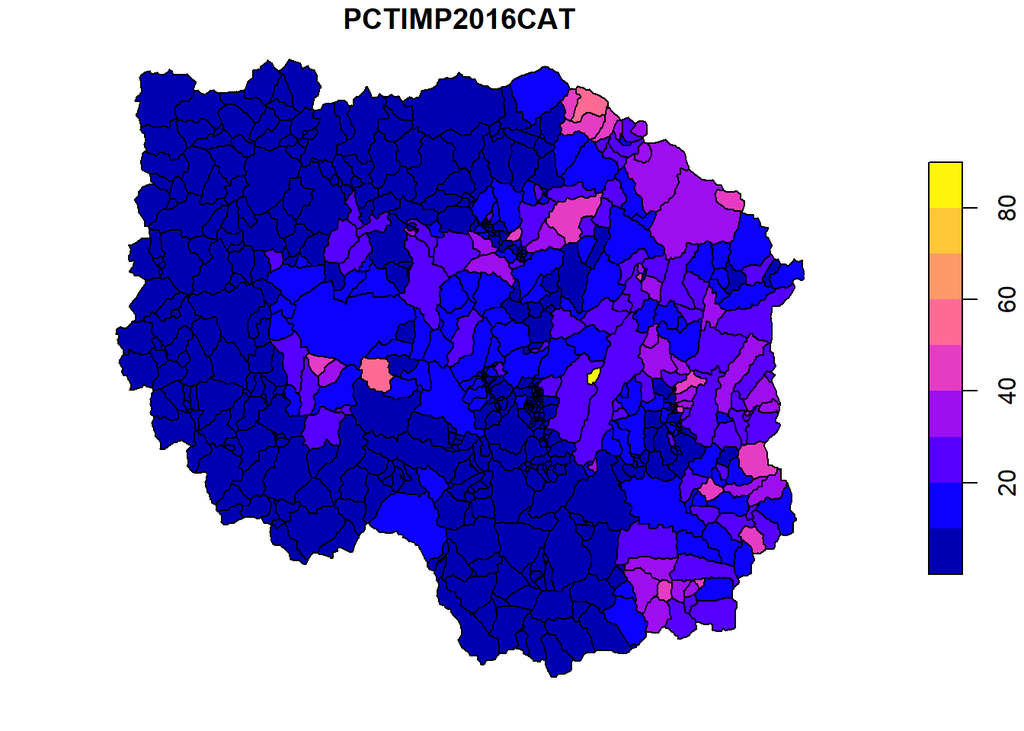

```r
twi <- nhdplusTools::get_catchment_characteristics("CAT_TWI", cat$FEATUREID)

twi <- dplyr::rename(twi, CAT_TWI = "characteristic_value")

imp <- StreamCatTools::sc_get_data("pctimp2016", 'catchment', cat$FEATUREID)

cat <- dplyr::left_join(cat, imp, by = c("FEATUREID" = "COMID"))
  # dplyr::left_join(twi, by = c("FEATUREID" = "comid"))

# plot(cat['CAT_TWI'])
plot(cat['PCTIMP2016CAT'])
```

With the two catalogs of characteristics above, we have access to nearly any characteristic imaginable and both even offer downstream accumulations of the variables. However, sometimes it is necessary to sample and accumulate data not already available. `nhdplusTools` supports accumulating drainage area and length and `hydroloom`, going forward, supports downstream accumulation more generically. Here, we’ll just use one of the examples pulled above to illustrate how this works.

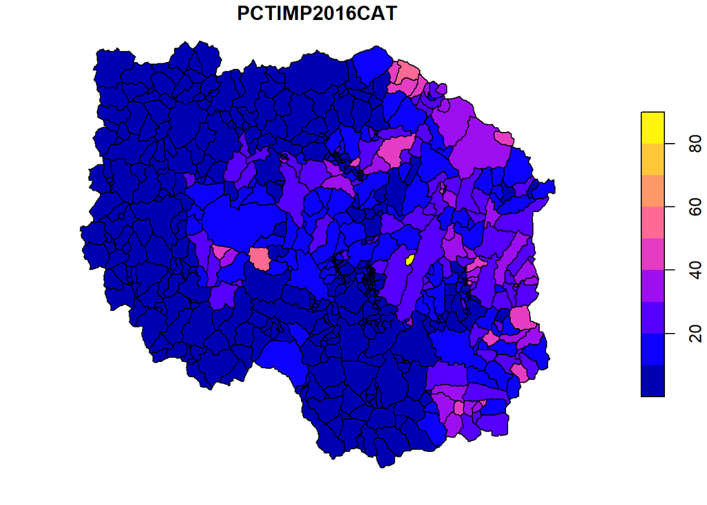

```r
accum_df <- sf::st_drop_geometry(fline) |>
  select(COMID, FromNode, ToNode, Divergence, AreaSqKM) |>
  hydroloom::add_toids() |>
  left_join(select(cat, -AreaSqKM), by = c("COMID" = "FEATUREID")) |>
  sf::st_sf() |>
  mutate(area_weighted_PCTIMP2016CAT =
           ifelse(is.na(PCTIMP2016CAT) & AreaSqKM == 0,
                  yes = 0, no = AreaSqKM * PCTIMP2016CAT))

accum_df <- accum_df |>
  mutate(tot_PCTIMP2016CAT =
           hydroloom::accumulate_downstream(accum_df, "area_weighted_PCTIMP2016CAT") /
           hydroloom::accumulate_downstream(accum_df, "AreaSqKM"))

plot(cat['PCTIMP2016CAT'])
```

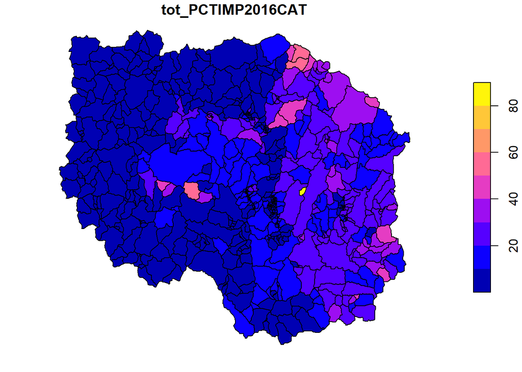

```r
plot(accum_df['tot_PCTIMP2016CAT'])
```

## Data access summary – web services and scalability

## R and Python Interoperability

We can us[Reticulate](https://rstudio.github.io/reticulate/index.html) to inter-operate easily between R and Python within RStudio and share objects between languages

```r
library(reticulate)
# reticulate::install_miniconda()
# create a new environment conda environment
# conda_create("r-reticulate")

# install NumPy and SciPy
# conda_install("r-reticulate", "scipy")
# conda_install("r-reticulate", "numpy")
# conda_install("r-reticulate", "pandas")
# indicate that we want to use a specific condaenv
use_condaenv("r-reticulate")
np <- import("numpy")
print(np$version$full_version)
```

```
[1] "1.24.3"
```

Simple examples from [reticulate - calling Python](https://rstudio.github.io/reticulate/articles/calling_python.html):

Import a module and call a function from Python:

```r
os <- import("os")
os$listdir(".")
```

```
 [1] ".git"                            ".gitignore"
 [3] ".Rproj.user"                     "Dam_Impact.html"
 [5] "Dam_Impact.ipynb"                "Dam_Impact.Rmd"
 [7] "environment.yml"                 "ICRW8_Geospatial_Workshop.Rproj"
 [9] "img"                             "README.md"
[11] "Relative_Elevation_Model.ipynb"  "Slides.html"
[13] "Slides.ipynb"                    "Slides.qmd"
[15] "Slides.rmarkdown"                "Slides_files"
```

Object conversion - When Python objects are returned to R they are converted to R objects by default - but you can deal in native Python types by choosing `convert=FALSE` in the import function

```r
# import numpy and specify no automatic Python to R conversion
np <- import("numpy", convert = FALSE)

# do some array manipulations with NumPy
a <- np$array(c(1:4))
print (a)
```

```
array([1, 2, 3, 4])
```

```r
sum <- a$cumsum()

# convert to R explicitly at the end
print (py_to_r(a))
```

```
[1] 1 2 3 4
```

```r
py_to_r(sum)
```

```
[1]  1  3  6 10
```

Passing Dataframes between Python and R:

```r
pd <- import("pandas")
penguins <- pd$read_csv("https://vincentarelbundock.github.io/Rdatasets/csv/modeldata/penguins.csv")
dplyr::glimpse(penguins)
```

```
Rows: 344
Columns: 8
$ `Unnamed: 0`      <dbl> 1, 2, 3, 4, 5, 6, 7, 8, 9, 10, 11, 12, 13, 14, 15, 1…
$ species           <chr> "Adelie", "Adelie", "Adelie", "Adelie", "Adelie", "A…
$ island            <chr> "Torgersen", "Torgersen", "Torgersen", "Torgersen", …
$ bill_length_mm    <dbl> 39.1, 39.5, 40.3, NaN, 36.7, 39.3, 38.9, 39.2, 34.1,…
$ bill_depth_mm     <dbl> 18.7, 17.4, 18.0, NaN, 19.3, 20.6, 17.8, 19.6, 18.1,…
$ flipper_length_mm <dbl> 181, 186, 195, NaN, 193, 190, 181, 195, 193, 190, 18…
$ body_mass_g       <dbl> 3750, 3800, 3250, NaN, 3450, 3650, 3625, 4675, 3475,…
$ sex               <list> "male", "female", "female", NaN, "female", "male", …
```

Or like this:

```python
import pandas as pd
penguins =pd.read_csv("https://vincentarelbundock.github.io/Rdatasets/csv/modeldata/penguins.csv")
print(penguins.head())
```

```
   Unnamed: 0 species     island  ...  flipper_length_mm  body_mass_g     sex
0           1  Adelie  Torgersen  ...              181.0       3750.0    male
1           2  Adelie  Torgersen  ...              186.0       3800.0  female
2           3  Adelie  Torgersen  ...              195.0       3250.0  female
3           4  Adelie  Torgersen  ...                NaN          NaN     NaN
4           5  Adelie  Torgersen  ...              193.0       3450.0  female

[5 rows x 8 columns]
```

Call Python from R:

```r
penguins <- py$penguins
dplyr::glimpse(penguins)
```

```
Rows: 344
Columns: 8
$ `Unnamed: 0`      <dbl> 1, 2, 3, 4, 5, 6, 7, 8, 9, 10, 11, 12, 13, 14, 15, 1…
$ species           <chr> "Adelie", "Adelie", "Adelie", "Adelie", "Adelie", "A…
$ island            <chr> "Torgersen", "Torgersen", "Torgersen", "Torgersen", …
$ bill_length_mm    <dbl> 39.1, 39.5, 40.3, NaN, 36.7, 39.3, 38.9, 39.2, 34.1,…
$ bill_depth_mm     <dbl> 18.7, 17.4, 18.0, NaN, 19.3, 20.6, 17.8, 19.6, 18.1,…
$ flipper_length_mm <dbl> 181, 186, 195, NaN, 193, 190, 181, 195, 193, 190, 18…
$ body_mass_g       <dbl> 3750, 3800, 3250, NaN, 3450, 3650, 3625, 4675, 3475,…
$ sex               <list> "male", "female", "female", NaN, "female", "male", …
```

Call R from Python:

```r
data(iris)
iris <- iris |>
  dplyr::filter(Petal.Length > 3)
```

```python
print(r.iris.head())
```

```
   Sepal.Length  Sepal.Width  Petal.Length  Petal.Width     Species
0           7.0          3.2           4.7          1.4  versicolor
1           6.4          3.2           4.5          1.5  versicolor
2           6.9          3.1           4.9          1.5  versicolor
3           5.5          2.3           4.0          1.3  versicolor
4           6.5          2.8           4.6          1.5  versicolor
```

```python
print(r.iris['Petal.Length'].min())
```

```
3.3
```

## Resources

### General

- [Awesome Geospatial](https://github.com/sacridini/Awesome-Geospatial)

### R

- [Hydroinformatics in R](https://vt-hydroinformatics.github.io/): Extensive Notes and exercises for a course on data analysis techniques in hydrology using the programming language R
- [Spatial Data Science by Edzar Pebesma and Roger Bivand](https://r-spatial.org/book/)
- [Geocomputation with R](https://r.geocompx.org/)
- r-spatial: Suite of fundamental packages for working with spatial data in R

#### Web Services

- [Accessing REST API (JSON data) using httr and jsonlite](https://rstudio-pubs-static.s3.amazonaws.com/480665_ba2655419209496dbb799f1c7d050673.html)

### Python

- [Datashader](https://datashader.org/): Accurately render even the largest data
- [GeoPandas](https://geopandas.org/en/stable/index.html)
- [HyRiver](https://docs.hyriver.io/index.html): a suite of Python packages that provides a unified API for retrieving geospatial/temporal data from various web services
- [Python Foundation for Spatial Analysis](https://courses.spatialthoughts.com/python-foundation.html)
- [Python for Geographic Data Analysis](https://pythongis.org/index.html)
- [gdptools](https://gdptools.readthedocs.io/en/latest/) A Python package for grid- or polygon-polygon area-weighted interpolation statistics
- [Intro to Python GIS](https://automating-gis-processes.github.io/CSC18/lessons/L2/geopandas-basics.html)
- [xarray](https://xarray.pydata.org/en/stable/): An open-source project and Python package that makes working with labeled multi-dimensional arrays simple, efficient, and fun!
- [rioxarray](https://corteva.github.io/rioxarray/stable/index.html): Rasterio xarray extension.
- [GeoPandas](https://geopandas.org/en/stable/): An open-source project to make working with geospatial data in python easier.
- [OSMnx](https://github.com/gboeing/osmnx): A Python package that lets you download and analyze geospatial data from OpenStreetMap.
- [Xarray Spatial](https://xarray-spatial.org/master/index.html): Implements common raster analysis functions using `numba` and provides an easy-to-install, easy-to-extend codebase for raster analysis.